# Assignment 2

Darren Chan

# 1 Introduction

Human cytomegalovirus (Human betaherpesvirus 5, HCMV, CMV) infections are found across a large proportion of the human population, though usually latent and asymptomatic (Nogalski et al. (2019)). However, they can sometimes cause infection in immunosuppressed individuals and have been associated with certain cancers (Griffiths, Baraniak, and Reeves (2015)) - in particular being observed to be induce a significant increase in transcription of HSATII, known to be associated with gene regulation of many different processes and implicated in many cancers (Hall et al. (2017)). To test the effects of HCMV infection on cells, Human lung fibroblasts (MRC-5/MRC5), human retinal pigment epithelial (ARPE-19), and human foreskin fibroblasts (HFF) were infected with HCMV as well as herpes simplex virus (HSV1) and adenovirus serotype 5 (Ad5) as comparisons/controls, and RNASeq data taken from each sample using Illumina HiSeq 2000 (Hall et al. (2017)).

# 2 Data Set Processing and Normalization (Results from Assignment 1)

## 2.1 Data Set Selection and Acquisition

The dataset that I chose is GSE120891 (Differential expression of genes in fibroblasts and epithelial cells infected with dsDNA viruses), which consists of RNA-seq data for fibroblast and epithelial cells that have either been infected by a mock virus (control condition) or infected with one of three different types of viruses (HCMV/human cytomegalovirus/human betaherpesvirus 5 with three different strains TB40, FIX, and AD169; HSV1/herpes simplex virus; and Ad5/adenovirus serotype 5) in the test conditions.

This dataset is of interest to me because it explores how cells change when exposed to viruses - either to try and fight off the invader or because of the effects of the virus within the cell as it aims to reproduce. This sort of data could hint at what sorts of molecular defenses the cell has - with potential applications in trying to boost the body’s natural immunity - as well as what sorts of pathways viruses trigger to trick the cell into accepting its DNA and taking over.

## 2.2 Data Set Cleaning

A total of 41763 genes were removed from the data set with a counts per million measurement too low to be reliably analyzed.

## 2.4 Dataset Overview Statistics

A total of 60725 transcripts were measured in the experiment. Of these, 18962 (31.2260189%) had a high enough counts per million measurement for the measurements to be reliable. Of the analyzable transcripts, 16600 (87.5435081%) had valid HUGO identifiers that could be found with 16583 (87.4538551%) corresponding to a unique HUGO identifier, giving a total final coverage of 16600 genes, 27.3363524% of the original data set.

Replicates were kept seperate throughout the process and in the final processed data. Since each experimental group only had 2 replicates, combining or averaging them together would not have made much of a difference to the overall size of the data set, and keeping both sets of data preserves more information, particularly if they diverge to a significant extent (with only 2 replicates, we cannot be sure which is the outlier - or if both are).

## 2.5 Data Normalization

The box plot and density plots indicate that there isn’t a particularly large amount of variation between the samples as a whole, with medians approximately equal in the boxplots and the density distributions roughly aligned as well. Nevertheless, normalization can still help.

Trimmed Mean of M-values (TMM) was chosen as the normalization method as this is the standard method for normalizing RNA-seq data where our assumption is that the genes are not differentially expressed.

As there was not very much variability between the samples in the first place, the post-normalized box plot appears quite similar to the pre-normalized box plot. However, the distribution of each group appears to be roughly in the same range, which indicates successful normalization.

Just as in the box plot, the density plot has not changed substantially either (as the original density plot was not highly variant in the first place). Nonetheless it can be observed that the distribution near the lower values of log-counts per million is slightly more clustered and regular than from before normalization; most of the variation itself is now in the actual shape of the distributions, as is desired.

The MDS plot shows roughly three larger clusters of samples, with the replicates tending to be very close to each other and cells from the same cell line tending to be relatively close to each other, which is more or less as would be expected from the experimental setup. The lack of any samples wildly far away from anything else indicates that none of them are overall significant outliers.

# 3 Differential Gene Expression and Preliminary ORA (Results from Assignment 2)

## 3.1 Differential Gene Expression

```r
# Break up the sample names into their constituent parts for mapping to factors
samples <- data.frame(lapply(colnames(counts_normalized),
                             FUN=function(x){
                               unlist(strsplit(x, split = "_"))[c(1, 2)]
                              }), stringsAsFactors = FALSE)
colnames(samples) <- colnames(counts_normalized)
rownames(samples) <- c("infection_agent", "cell_type")
#samples <- data.frame(t(samples))

# Need to deal with various inconsistencies in the naming scheme
# The LNA samples have the infection agent and cell type swapped around
cell_types <- samples["cell_type", ]
columns_to_swap <- cell_types == "Mock" | cell_types == "HCMV"
samples["cell_type", columns_to_swap] <- samples["infection_agent", columns_to_swap]
samples["infection_agent", columns_to_swap] <- cell_types[columns_to_swap]

# The Ad5 and HSV samples do not have cell type labelled (they are all MRC5)
missing_cell_types <- grepl("^[0-9]", samples["cell_type", ])
samples["cell_type", missing_cell_types] <- "MRC5"

# Strip the extra characters off of the "TB40/E" strain
samples["infection_agent", ] <- gsub("TB40/E", "TB40", samples["infection_agent", ])

# Annotate HCMV strains as HCMV
samples["infection_agent", ] <- gsub("(AD169|FIX|TB40)",
                                     "HCMV-\\1", samples["infection_agent", ])

# Samples labelled just "HCMV" are actually HCMV-TB40
samples["infection_agent", ] <- gsub("^HCMV$", "HCMV-TB40", samples["infection_agent", ])

# Rename references to HFF cells
hff_cells <- grepl("LNA", samples["cell_type", ])
samples["cell_type", hff_cells] <- "HFF"

samples <- data.frame(t(samples))
knitr::kable(samples, type="html", caption = "Dataset Samples by Infection Agent and Cell Type")
```

Table 3.1: Dataset Samples by Infection Agent and Cell Type

|  | infection_agent | cell_type |
| --- | --- | --- |
| AD169_MRC5_1 | HCMV-AD169 | MRC5 |
| AD169_MRC5_2 | HCMV-AD169 | MRC5 |
| Ad5_1 | Ad5 | MRC5 |
| FIX_MRC5_1 | HCMV-FIX | MRC5 |
| FIX_MRC5_2 | HCMV-FIX | MRC5 |
| Mock_24h_1 | Mock | MRC5 |
| Mock_24h_2 | Mock | MRC5 |
| Mock_ARPE19_1 | Mock | ARPE19 |
| Mock_ARPE19_2 | Mock | ARPE19 |
| Mock_9h_1 | Mock | MRC5 |
| Mock_9h_2 | Mock | MRC5 |
| Mock_MRC5_1 | Mock | MRC5 |
| Mock_MRC5_2 | Mock | MRC5 |
| Ad5_2 | Ad5 | MRC5 |
| HSV_1 | HSV | MRC5 |
| HSV_2 | HSV | MRC5 |
| NT-LNA_Mock_1 | Mock | HFF |
| HSII-LNA_Mock_1 | Mock | HFF |
| NT-LNA_HCMV_1 | HCMV-TB40 | HFF |
| HSII-LNA_HCMV_1 | HCMV-TB40 | HFF |
| NT-LNA_Mock_2 | Mock | HFF |
| HSII-LNA_Mock_2 | Mock | HFF |
| NT-LNA_HCMV_2 | HCMV-TB40 | HFF |
| HSII-LNA_HCMV_2 | HCMV-TB40 | HFF |
| TB40e_ARPE19_1 | HCMV-TB40e | ARPE19 |
| TB40e_ARPE19_1.1 | HCMV-TB40e | ARPE19 |
| TB40e_MRC5_1 | HCMV-TB40e | MRC5 |
| TB40e_MRC5_1.1 | HCMV-TB40e | MRC5 |
| TB40/E_MRC5_1 | HCMV-TB40 | MRC5 |
| TB40/E_MRC5_1.1 | HCMV-TB40 | MRC5 |

Sample names were mapped to the two most important factors (infection agent and cell type) (3.1). Given the inconsistent nature of the naming scheme (e.g. infection agent and cell type not in a consistent order, cell type not always explictly listed), a number of different manipulations were required.

```r
# Removed unwanted samples
excluded_columns <- (grepl("HSV|Ad5", samples$infection_agent) | grepl("ARPE19|HFF",
                                                                        samples$cell_type))
normalized_samples_of_interest <- cbind(counts_normalized_annot[1:3], counts_normalized[, !excluded_columns])
samples <- samples[!excluded_columns, ]
samples <- droplevels(samples)

# Add new column in samples for strain
strains <- gsub("(HCMV-)", "", samples$infection_agent)
samples <- cbind(samples, strains)
samples$infection_agent <- gsub("HCMV.*", "HCMV", samples$infection_agent)

# Remove any all-zero rows (because of removed samples)
zero_rows <- apply(normalized_samples_of_interest[, -(1:3)], 1, function(x) !all(x == 0))
normalized_samples_of_interest <- normalized_samples_of_interest[zero_rows, ]

knitr::kable(head(normalized_samples_of_interest), type="html",
             caption = "Samples of Normalized Expression Data for Samples of Interest")
```

Table 3.2: Samples of Normalized Expression Data for Samples of Interest

|  | ensembl_gene_id | hgnc_symbol | ensembl_gene_id_version | AD169_MRC5_1 | AD169_MRC5_2 | FIX_MRC5_1 | FIX_MRC5_2 | Mock_24h_1 | Mock_24h_2 | Mock_9h_1 | Mock_9h_2 | Mock_MRC5_1 | Mock_MRC5_2 | TB40e_MRC5_1 | TB40e_MRC5_1.1 | TB40/E_MRC5_1 | TB40/E_MRC5_1.1 |
| --- | --- | --- | --- | --- | --- | --- | --- | --- | --- | --- | --- | --- | --- | --- | --- | --- | --- |
| TSPAN6 | ENSG00000000003 | TSPAN6 | ENSG00000000003.14 | 32.41890 | 34.17338 | 30.51871 | 27.24597 | 29.68959 | 32.53850 | 37.38703 | 36.63140 | 37.65682 | 45.534693 | 30.24918 | 28.17100 | 32.10155 | 28.94545 |
| DPM1 | ENSG00000000419 | DPM1 | ENSG00000000419.12 | 34.76130 | 35.25825 | 48.28128 | 51.79902 | 46.56444 | 43.80183 | 40.45526 | 42.00982 | 34.21744 | 33.966988 | 53.36737 | 45.02834 | 56.20626 | 56.09118 |
| SCYL3 | ENSG00000000457 | SCYL3 | ENSG00000000457.13 | 23.70515 | 22.51103 | 23.93489 | 22.25615 | 15.35231 | 16.51955 | 16.81848 | 15.84453 | 21.07724 | 25.238629 | 32.77953 | 27.60531 | 27.18921 | 24.59613 |
| C1orf112 | ENSG00000000460 | C1orf112 | ENSG00000000460.16 | 35.79196 | 32.90770 | 21.19164 | 19.80085 | 27.78641 | 27.15714 | 21.59129 | 20.78686 | 18.25518 | 6.309657 | 21.96803 | 18.78066 | 22.27687 | 13.79783 |
| CFH | ENSG00000000971 | CFH | ENSG00000000971.15 | 40.66416 | 28.83944 | 17.48825 | 23.76102 | 79.42600 | 75.46430 | 81.36508 | 91.14241 | 99.03655 | 119.673166 | 32.77953 | 61.54627 | 30.84490 | 22.19651 |
| FUCA2 | ENSG00000001036 | FUCA2 | ENSG00000001036.13 | 109.53089 | 110.20462 | 100.12879 | 106.29095 | 131.44622 | 118.76554 | 108.29737 | 102.33533 | 128.84452 | 131.240871 | 114.32579 | 120.15100 | 118.23879 | 119.38122 |

In our analysis, we will only be comparing CMV-infected samples with mock-infected negative controls on MRC5 cells due to large differences in the expression profiles of other infection agents and cell types. Therefore, the HSV1 and Ad5 infection samples as well as the ARPE19 and HFF cell type samples needed to be removed (Table 3.2).

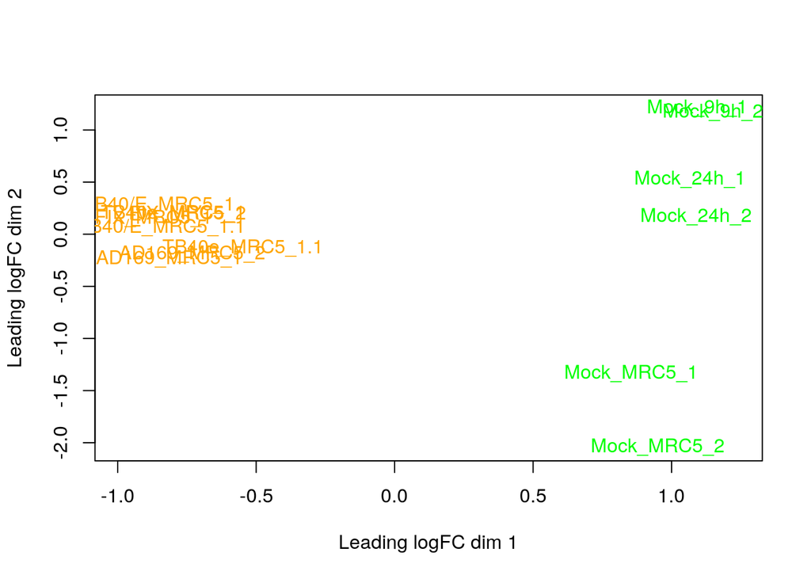

Figure 3.1: MDS Plot of Normalized Data (Coloured by Infection Type - HCMV (Orange), Mock (Green))

```r
# Arrange data into matrix
heatmap_matrix <- normalized_samples_of_interest[, -(1:3)]
rownames(heatmap_matrix) <- normalized_samples_of_interest$ensembl_gene_id
heatmap_matrix <- t(scale(t(heatmap_matrix)))

# Map cell types to colours on MDS plot
infection_type_colours <- samples$infection_agent
infection_type_colours <- gsub("HCMV", "orange", infection_type_colours)
infection_type_colours <- gsub("Mock", "green", infection_type_colours)

# Draw MDS plot of data, coloured by cell type
limma::plotMDS(heatmap_matrix, col = infection_type_colours)
```

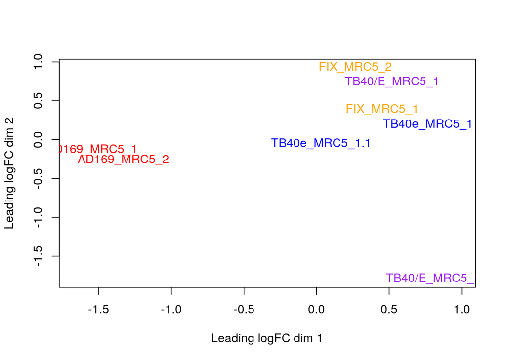

```r
# Map strains to colours on MDS plot
strain_type_colours <- samples$strains[samples$infection_agent != "Mock"]
strain_type_colours <- gsub("AD169", "red", strain_type_colours)
strain_type_colours <- gsub("FIX", "orange", strain_type_colours)
strain_type_colours <- gsub("TB40e", "blue", strain_type_colours)
strain_type_colours <- gsub("TB40", "purple", strain_type_colours)

# Draw MDS plot of data, coloured by cell type
limma::plotMDS(heatmap_matrix[, samples$infection_agent != "Mock"], col = strain_type_colours)
```

The first step in determining differences between our two groups of choice is to choose the factors used in the model. An MDS plot of the normalized data (using the Limma package Ritchie et al. (2015)) coloured by infection type (CMV or mock) is shown in Figure 3.1, which demonstrates quite clearly the differing profile between the two treatments. However, it does not explain all of the variability; colouring the same plot (with the mock treatment removed to zoom in on the infected samples) by the HCMV strain (Figure 3.2 shows that there is also some relationship with the strain that was used in the infection. This indicates that in addition to our main factor of analysis (CMV vs. mock transfections), strain should also be taken into account.

```r
# Limma linear model - code adapted from Ruth Isserlin (2020)
model_design <- model.matrix(~ samples$infection_agent)
expressionMatrix <- as.matrix(normalized_samples_of_interest[, -(1:3)])
rownames(expressionMatrix) <- normalized_samples_of_interest$ensembl_gene_id
minimalSet <- Biobase::ExpressionSet(assayData = expressionMatrix)

# Fit data to model and compute differential expression
fit <- limma::lmFit(minimalSet, model_design)
fit2 <- limma::eBayes(fit, trend=TRUE)
topfit <- limma::topTable(fit2,
                   coef=ncol(model_design),
                   adjust.method = "BH",
                   number = nrow(expressionMatrix))
# Merge hgnc names and ensembl identifiers to topfit table
output_hits <- merge(normalized_samples_of_interest[, 1:3],
                     topfit,by.y=0, by.x=1, all.y=TRUE)
# Sort table by pvalue
output_hits <- output_hits[order(output_hits$P.Value), ]

# Get the number of genes that pass the threshold (p = 0.05)
(num_significant_genes_simple <- length(which(output_hits$P.Value < 0.05)))
```

```
## [1] 10127
```

```r
# Multiple hypothesis testing correction
significant_genes_logical <- p.adjust(output_hits$P.Value, method = "bonferroni") < 0.05
(num_significant_genes_corrected <- sum(significant_genes_logical))
```

```
## [1] 1793
```

The p-values were corrected using the Bonferroni multiple hypothesis correction method, which was chosen due to the large number of samples which passed the threshold (making it feasible to narrow down the search more stringently to get rid of false positives) and the relatively small number of samples and hypotheses (which means that the correction is not as overly conservative as it might be in other samples). 1793 passed the correction.

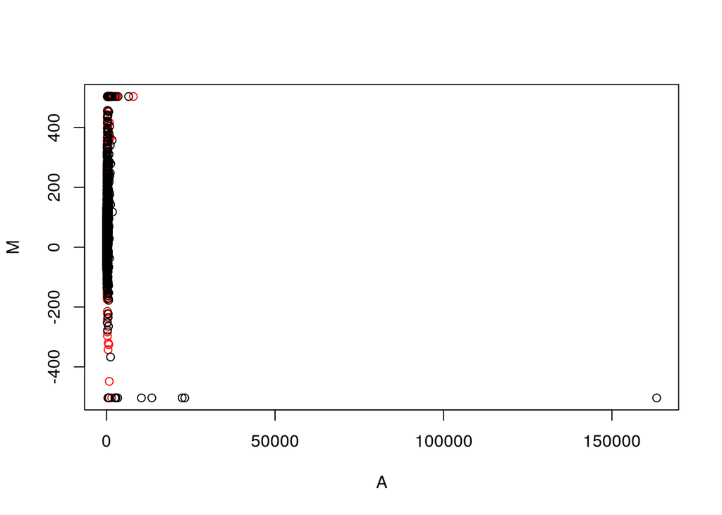

Figure 3.3: MA Plot of Differentially Expressed Genes

```r
colours <- ifelse(significant_genes_logical, "red", "black")

# Show the amount of differentially expressed genes using an MA Plot
edgeR::maPlot(logAbundance = output_hits$AveExpr, logFC = output_hits$logFC, col = colours)
```

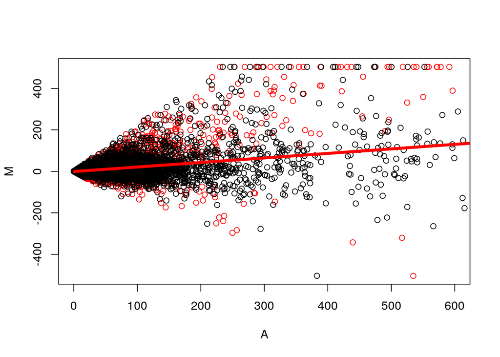

Figure 3.4: MA Plot of Differentially Expressed Genes (Zoomed In)

```r
# Remove extreme outliers
no_outliers <- output_hits[output_hits$logFC < 5000, ]

# Zoom in on the main area of the graph
edgeR::maPlot(logAbundance = no_outliers$AveExpr, logFC = no_outliers$logFC,
              xlim = c(0, 600), lowess = TRUE, col = colours)
```

MA Plots were made of the differentially expressed genes using the EdgeR package (McCarthy, Chen, and Smyth (2012)), with the Bonferroni-corrected statistically significant genes highlighted in red. Figure 3.3 is utterly dominated by the large outlier with an expression value of about 160000, which makes it largely useless for analyzing the data. A better overview of the data can be gained by zooming into the <600 mean average (A) area and removing the most extreme outliers for the calculation of the central curve (Figure 3.4), which indicates a somewhat upwards-sloping center - as this data is already normalized, this may be indicative of a real difference in total expression between the two treatments. There is not much of a pattern in the statistically significant genes, which appears to have a similar distribution to the rest of the geneset, but there does seem to be some bias away from the midpoint line, which is to be expected.

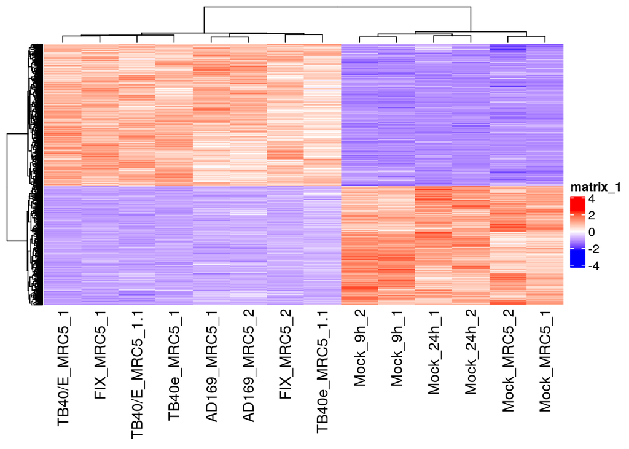

Figure 3.5: Heatmap of Statistically Significantly Differentially Expressed Genes

```r
# Visualize top hits using a heatmap - code adapted from Ruth Isserlin (2020)
top_hits <- output_hits$ensembl_gene_id[p.adjust(output_hits$P.Value, method = "bonferroni") < 0.05]
heatmap_matrix_tophits <- t(scale(t(heatmap_matrix[which(rownames(heatmap_matrix) %in% top_hits),])))

if(min(heatmap_matrix_tophits) == 0){
  heatmap_col = circlize::colorRamp2(c(0, max(heatmap_matrix_tophits)), c("white", "red"))
} else {
  heatmap_col = circlize::colorRamp2(c(min(heatmap_matrix_tophits), 0,
                             max(heatmap_matrix_tophits)), c("blue", "white", "red"))
}

(current_heatmap <- ComplexHeatmap::Heatmap(as.matrix(heatmap_matrix_tophits),
                                            cluster_rows = TRUE,
                                            cluster_columns = TRUE,
                                            show_row_dend = TRUE,
                                            show_column_dend = TRUE,
                                            col = heatmap_col,
                                            show_column_names = TRUE,
                                            show_row_names = FALSE,
                                            show_heatmap_legend = TRUE))
```

## 3.2 Thresholded Over-Representation Analysis

```r
# How many genesets were returned with what thresholds?
if (!requireNamespace("gprofiler2", quietly = TRUE)) {
  install.packages("gprofiler2")
}

# GO query
significant_genes <- output_hits[significant_genes_logical,]
go_ora <- gprofiler2::gost(significant_genes$ensembl_gene_id, correction_method = "bonferroni", sources = "GO")
length(go_ora$result$term_name)
```

```
## [1] 291
```

```r
knitr::kable(go_ora$result[1:30, c("term_id", "term_name", "term_size", "p_value", "intersection_size",
                                   "precision", "recall", "source")],
                                    type="html", caption = "Thresholded Over-Representation Analysis on GO")
```

Table 3.3: Thresholded Over-Representation Analysis on GO

| term_id | term_name | term_size | p_value | intersection_size | precision | recall | source |
| --- | --- | --- | --- | --- | --- | --- | --- |
| GO:0044444 | cytoplasmic part | 9760 | 0 | 1073 | 0.6495157 | 0.1099385 | GO:CC |
| GO:0005737 | cytoplasm | 11620 | 0 | 1223 | 0.7403148 | 0.1052496 | GO:CC |
| GO:0044424 | intracellular part | 14552 | 0 | 1424 | 0.8619855 | 0.0978560 | GO:CC |
| GO:0005622 | intracellular | 14596 | 0 | 1426 | 0.8631961 | 0.0976980 | GO:CC |
| GO:0012505 | endomembrane system | 4490 | 0 | 547 | 0.3311138 | 0.1218263 | GO:CC |
| GO:0009653 | anatomical structure morphogenesis | 2764 | 0 | 376 | 0.2378242 | 0.1360347 | GO:BP |
| GO:0005515 | protein binding | 12715 | 0 | 1286 | 0.7943175 | 0.1011404 | GO:MF |
| GO:0043226 | organelle | 13667 | 0 | 1342 | 0.8123487 | 0.0981927 | GO:CC |
| GO:0031982 | vesicle | 3891 | 0 | 476 | 0.2881356 | 0.1223336 | GO:CC |
| GO:0043227 | membrane-bounded organelle | 12536 | 0 | 1244 | 0.7530266 | 0.0992342 | GO:CC |
| GO:0070161 | anchoring junction | 561 | 0 | 109 | 0.0659806 | 0.1942959 | GO:CC |
| GO:0005912 | adherens junction | 546 | 0 | 106 | 0.0641646 | 0.1941392 | GO:CC |
| GO:0048731 | system development | 4967 | 0 | 581 | 0.3674889 | 0.1169720 | GO:BP |
| GO:0016043 | cellular component organization | 6454 | 0 | 720 | 0.4554080 | 0.1115587 | GO:BP |
| GO:0043229 | intracellular organelle | 12818 | 0 | 1260 | 0.7627119 | 0.0982993 | GO:CC |
| GO:0022008 | neurogenesis | 1656 | 0 | 240 | 0.1518027 | 0.1449275 | GO:BP |
| GO:0005783 | endoplasmic reticulum | 1925 | 0 | 264 | 0.1598063 | 0.1371429 | GO:CC |
| GO:0030054 | cell junction | 1312 | 0 | 196 | 0.1186441 | 0.1493902 | GO:CC |
| GO:0048699 | generation of neurons | 1556 | 0 | 228 | 0.1442125 | 0.1465296 | GO:BP |
| GO:0031090 | organelle membrane | 3500 | 0 | 425 | 0.2572639 | 0.1214286 | GO:CC |
| GO:0007399 | nervous system development | 2400 | 0 | 318 | 0.2011385 | 0.1325000 | GO:BP |
| GO:0031175 | neuron projection development | 1004 | 0 | 163 | 0.1030993 | 0.1623506 | GO:BP |
| GO:0071840 | cellular component organization or biogenesis | 6636 | 0 | 731 | 0.4623656 | 0.1101567 | GO:BP |
| GO:0048666 | neuron development | 1131 | 0 | 178 | 0.1125870 | 0.1573828 | GO:BP |
| GO:0048856 | anatomical structure development | 6028 | 0 | 674 | 0.4263125 | 0.1118115 | GO:BP |
| GO:0000902 | cell morphogenesis | 1050 | 0 | 168 | 0.1062619 | 0.1600000 | GO:BP |
| GO:0005925 | focal adhesion | 403 | 0 | 83 | 0.0502421 | 0.2059553 | GO:CC |
| GO:0005924 | cell-substrate adherens junction | 406 | 0 | 83 | 0.0502421 | 0.2044335 | GO:CC |
| GO:0048468 | cell development | 2196 | 0 | 294 | 0.1859583 | 0.1338798 | GO:BP |
| GO:0007275 | multicellular organism development | 5532 | 0 | 625 | 0.3953194 | 0.1129790 | GO:BP |

```r
# Reactome query
reactome_ora <- gprofiler2::gost(significant_genes$ensembl_gene_id, correction_method = "gSCS", sources = "REAC")
length(reactome_ora$result$term_name)
```

```
## [1] 17
```

```r
knitr::kable(reactome_ora$result[, c("term_id", "term_name", "term_size", "p_value",
                                     "intersection_size", "precision", "recall")],
                                      type="html", caption = "Thresholded Over-Representation Analysis on Reactome")
```

Table 3.4: Thresholded Over-Representation Analysis on Reactome

| term_id | term_name | term_size | p_value | intersection_size | precision | recall |
| --- | --- | --- | --- | --- | --- | --- |
| REAC:R-HSA-1474244 | Extracellular matrix organization | 298 | 0.0000003 | 63 | 0.063 | 0.2114094 |
| REAC:R-HSA-191273 | Cholesterol biosynthesis | 24 | 0.0000017 | 14 | 0.014 | 0.5833333 |
| REAC:R-HSA-9006934 | Signaling by Receptor Tyrosine Kinases | 454 | 0.0000528 | 78 | 0.078 | 0.1718062 |
| REAC:R-HSA-1474290 | Collagen formation | 89 | 0.0002089 | 25 | 0.025 | 0.2808989 |
| REAC:R-HSA-2022090 | Assembly of collagen fibrils and other multimeric structures | 60 | 0.0006966 | 19 | 0.019 | 0.3166667 |
| REAC:R-HSA-1474228 | Degradation of the extracellular matrix | 140 | 0.0008863 | 32 | 0.032 | 0.2285714 |
| REAC:R-HSA-3000178 | ECM proteoglycans | 75 | 0.0018424 | 21 | 0.021 | 0.2800000 |
| REAC:R-HSA-1442490 | Collagen degradation | 64 | 0.0020588 | 19 | 0.019 | 0.2968750 |
| REAC:R-HSA-8874081 | MET activates PTK2 signaling | 30 | 0.0041285 | 12 | 0.012 | 0.4000000 |
| REAC:R-HSA-1650814 | Collagen biosynthesis and modifying enzymes | 67 | 0.0043323 | 19 | 0.019 | 0.2835821 |
| REAC:R-HSA-8948216 | Collagen chain trimerization | 44 | 0.0159582 | 14 | 0.014 | 0.3181818 |
| REAC:R-HSA-1566948 | Elastic fibre formation | 44 | 0.0159582 | 14 | 0.014 | 0.3181818 |
| REAC:R-HSA-8875878 | MET promotes cell motility | 40 | 0.0237144 | 13 | 0.013 | 0.3250000 |
| REAC:R-HSA-6806834 | Signaling by MET | 77 | 0.0365170 | 19 | 0.019 | 0.2467532 |
| REAC:R-HSA-6807062 | Cholesterol biosynthesis via lathosterol | 4 | 0.0395192 | 4 | 0.004 | 1.0000000 |
| REAC:R-HSA-6807047 | Cholesterol biosynthesis via desmosterol | 4 | 0.0395192 | 4 | 0.004 | 1.0000000 |
| REAC:R-HSA-2129379 | Molecules associated with elastic fibres | 37 | 0.0473275 | 12 | 0.012 | 0.3243243 |

```r
# WikiPathways query
wikipathways_ora <- gprofiler2::gost(significant_genes$ensembl_gene_id, correction_method = "gSCS", sources = "WP")
length(wikipathways_ora$result$term_name)
```

```
## [1] 6
```

```r
knitr::kable(wikipathways_ora$result[, c("term_id", "term_name", "term_size", "p_value",
                                         "intersection_size", "precision", "recall")],
                                          type="html", caption = "Thresholded Over-Representation Analysis on WikiPathways")
```

Table 3.5: Thresholded Over-Representation Analysis on WikiPathways

| term_id | term_name | term_size | p_value | intersection_size | precision | recall |
| --- | --- | --- | --- | --- | --- | --- |
| WP:WP197 | Cholesterol Biosynthesis Pathway | 15 | 0.0000022 | 11 | 0.0160819 | 0.7333333 |
| WP:WP306 | Focal Adhesion | 198 | 0.0044827 | 40 | 0.0584795 | 0.2020202 |
| WP:WP4540 | Pathways Regulating Hippo Signaling | 99 | 0.0093775 | 24 | 0.0350877 | 0.2424242 |
| WP:WP3932 | Focal Adhesion-PI3K-Akt-mTOR-signaling pathway | 303 | 0.0305693 | 52 | 0.0760234 | 0.1716172 |
| WP:WP3963 | Mevalonate pathway | 7 | 0.0327112 | 5 | 0.0073099 | 0.7142857 |
| WP:WP3967 | miR-509-3p alteration of YAP1/ECM axis | 18 | 0.0353427 | 8 | 0.0116959 | 0.4444444 |

```r
# Get the list of upregulated genes (compared to control/mock)
# We are looking for low logFC values because it is currently reversed (fold-difference of mock compared to HCMV)
upregulated_genes <- output_hits[significant_genes_logical & output_hits$logFC < 0, ]
nrow(upregulated_genes)
```

```
## [1] 976
```

```r
# Rerun the analyses with the upregulated genes
go_ora_up <- gprofiler2::gost(upregulated_genes$ensembl_gene_id, correction_method = "bonferroni", sources = "GO")
length(go_ora_up$result$term_name)
```

```
## [1] 55
```

```r
knitr::kable(go_ora_up$result[1:30, c("term_id", "term_name", "term_size", "p_value", "intersection_size",
                                   "precision", "recall", "source")], type="html",
             caption = "Thresholded Over-Representation Analysis on GO for Upregualated Genes")
```

Table 3.6: Thresholded Over-Representation Analysis on GO for Upregualated Genes

| term_id | term_name | term_size | p_value | intersection_size | precision | recall | source |
| --- | --- | --- | --- | --- | --- | --- | --- |
| GO:0044444 | cytoplasmic part | 9760 | 0.0000001 | 558 | 0.6206897 | 0.0571721 | GO:CC |
| GO:0005737 | cytoplasm | 11620 | 0.0000001 | 643 | 0.7152392 | 0.0553356 | GO:CC |
| GO:0031090 | organelle membrane | 3500 | 0.0000003 | 241 | 0.2680756 | 0.0688571 | GO:CC |
| GO:0005622 | intracellular | 14596 | 0.0000005 | 768 | 0.8542825 | 0.0526172 | GO:CC |
| GO:0044424 | intracellular part | 14552 | 0.0000006 | 766 | 0.8520578 | 0.0526388 | GO:CC |
| GO:0044429 | mitochondrial part | 1056 | 0.0000013 | 95 | 0.1056730 | 0.0899621 | GO:CC |
| GO:1902653 | secondary alcohol biosynthetic process | 75 | 0.0000014 | 20 | 0.0235018 | 0.2666667 | GO:BP |
| GO:0005743 | mitochondrial inner membrane | 477 | 0.0000031 | 54 | 0.0600667 | 0.1132075 | GO:CC |
| GO:0006695 | cholesterol biosynthetic process | 71 | 0.0000038 | 19 | 0.0223267 | 0.2676056 | GO:BP |
| GO:0016126 | sterol biosynthetic process | 80 | 0.0000050 | 20 | 0.0235018 | 0.2500000 | GO:BP |
| GO:0046165 | alcohol biosynthetic process | 173 | 0.0000052 | 30 | 0.0352526 | 0.1734104 | GO:BP |
| GO:0031975 | envelope | 1202 | 0.0000070 | 102 | 0.1134594 | 0.0848586 | GO:CC |
| GO:0031967 | organelle envelope | 1202 | 0.0000070 | 102 | 0.1134594 | 0.0848586 | GO:CC |
| GO:0005739 | mitochondrion | 1621 | 0.0000113 | 127 | 0.1412681 | 0.0783467 | GO:CC |
| GO:0019866 | organelle inner membrane | 538 | 0.0000127 | 57 | 0.0634038 | 0.1059480 | GO:CC |
| GO:0031966 | mitochondrial membrane | 710 | 0.0000132 | 69 | 0.0767519 | 0.0971831 | GO:CC |
| GO:0044297 | cell body | 576 | 0.0000240 | 59 | 0.0656285 | 0.1024306 | GO:CC |
| GO:0005740 | mitochondrial envelope | 753 | 0.0000277 | 71 | 0.0789766 | 0.0942895 | GO:CC |
| GO:1902652 | secondary alcohol metabolic process | 161 | 0.0000775 | 27 | 0.0317274 | 0.1677019 | GO:BP |
| GO:0043025 | neuronal cell body | 506 | 0.0001469 | 52 | 0.0578420 | 0.1027668 | GO:CC |
| GO:0006066 | alcohol metabolic process | 372 | 0.0001895 | 44 | 0.0517039 | 0.1182796 | GO:BP |
| GO:0005515 | protein binding | 12715 | 0.0007205 | 682 | 0.7750000 | 0.0536374 | GO:MF |
| GO:0036477 | somatodendritic compartment | 843 | 0.0010166 | 72 | 0.0800890 | 0.0854093 | GO:CC |
| GO:1901617 | organic hydroxy compound biosynthetic process | 266 | 0.0011605 | 34 | 0.0399530 | 0.1278195 | GO:BP |
| GO:0005759 | mitochondrial matrix | 475 | 0.0016817 | 47 | 0.0522803 | 0.0989474 | GO:CC |
| GO:0006694 | steroid biosynthetic process | 198 | 0.0017787 | 28 | 0.0329025 | 0.1414141 | GO:BP |
| GO:0016020 | membrane | 9701 | 0.0030018 | 529 | 0.5884316 | 0.0545305 | GO:CC |
| GO:0008203 | cholesterol metabolic process | 148 | 0.0038614 | 23 | 0.0270270 | 0.1554054 | GO:BP |
| GO:0022857 | transmembrane transporter activity | 1066 | 0.0062758 | 85 | 0.0965909 | 0.0797373 | GO:MF |
| GO:0097458 | neuron part | 1771 | 0.0066511 | 124 | 0.1379310 | 0.0700169 | GO:CC |

```r
reactome_ora_up <- gprofiler2::gost(upregulated_genes$ensembl_gene_id, correction_method = "gSCS", sources = "REAC")
length(reactome_ora_up$result$term_name)
```

```
## [1] 8
```

```r
knitr::kable(reactome_ora_up$result[, c("term_id", "term_name", "term_size", "p_value",
                                     "intersection_size", "precision", "recall")], type="html",
             caption = "Thresholded Over-Representation Analysis on Reactome for Upregulated Genes")
```

Table 3.7: Thresholded Over-Representation Analysis on Reactome for Upregulated Genes

| term_id | term_name | term_size | p_value | intersection_size | precision | recall |
| --- | --- | --- | --- | --- | --- | --- |
| REAC:R-HSA-191273 | Cholesterol biosynthesis | 24 | 0.0000000 | 14 | 0.0265655 | 0.5833333 |
| REAC:R-HSA-6807047 | Cholesterol biosynthesis via desmosterol | 4 | 0.0028093 | 4 | 0.0075901 | 1.0000000 |
| REAC:R-HSA-6807062 | Cholesterol biosynthesis via lathosterol | 4 | 0.0028093 | 4 | 0.0075901 | 1.0000000 |
| REAC:R-HSA-1430728 | Metabolism | 2071 | 0.0030312 | 144 | 0.2732448 | 0.0695316 |
| REAC:R-HSA-2426168 | Activation of gene expression by SREBF (SREBP) | 40 | 0.0087728 | 10 | 0.0189753 | 0.2500000 |
| REAC:R-HSA-556833 | Metabolism of lipids | 729 | 0.0093944 | 62 | 0.1176471 | 0.0850480 |
| REAC:R-HSA-71403 | Citric acid cycle (TCA cycle) | 22 | 0.0299801 | 7 | 0.0132827 | 0.3181818 |
| REAC:R-HSA-1268020 | Mitochondrial protein import | 65 | 0.0342956 | 12 | 0.0227704 | 0.1846154 |

```r
wikipathways_ora_up <- gprofiler2::gost(upregulated_genes$ensembl_gene_id, correction_method = "gSCS", sources = "WP")
length(wikipathways_ora_up$result$term_name)
```

```
## [1] 3
```

```r
knitr::kable(wikipathways_ora_up$result[, c("term_id", "term_name", "term_size", "p_value",
                                         "intersection_size", "precision", "recall")], type="html",
             caption = "Thresholded Over-Representation Analysis on WikiPathways for Upregulated Genes")
```

Table 3.8: Thresholded Over-Representation Analysis on WikiPathways for Upregulated Genes

| term_id | term_name | term_size | p_value | intersection_size | precision | recall |
| --- | --- | --- | --- | --- | --- | --- |
| WP:WP197 | Cholesterol Biosynthesis Pathway | 15 | 0.0000000 | 11 | 0.0321637 | 0.7333333 |
| WP:WP3963 | Mevalonate pathway | 7 | 0.0010592 | 5 | 0.0146199 | 0.7142857 |
| WP:WP78 | TCA Cycle (aka Krebs or citric acid cycle) | 18 | 0.0308575 | 6 | 0.0175439 | 0.3333333 |

The genesets associated with genes upregulated when infecting with HCMV as opposed to the mock infection skew very strongly towards biosynthetic pathways (Tables 3.6, 3.7, and 3.8) - in fact, other than the more general GO terms and those relating to cellular location, all of them relate to a biosynthetic pathway in some shape or form. There are none of the signalling or cell structure/interaction annotations that were seen in the combined list.

```r
# Get the list of downregulated genes
downregulated_genes <- output_hits[significant_genes_logical & output_hits$logFC > 0, ]
nrow(downregulated_genes)
```

```
## [1] 817
```

```r
# Rerun the analyses with the downregulated genes
go_ora_down <- gprofiler2::gost(downregulated_genes$ensembl_gene_id, correction_method = "bonferroni", sources = "GO")
length(go_ora_down$result$term_name)
```

```
## [1] 311
```

```r
knitr::kable(go_ora_down$result[1:30, c("term_id", "term_name", "term_size", "p_value", "intersection_size",
                                   "precision", "recall", "source")], type="html",
             caption = "Thresholded Over-Representation Analysis on GO for Downregulated Genes")
```

Table 3.9: Thresholded Over-Representation Analysis on GO for Downregulated Genes

| term_id | term_name | term_size | p_value | intersection_size | precision | recall | source |
| --- | --- | --- | --- | --- | --- | --- | --- |
| GO:0005925 | focal adhesion | 403 | 0 | 72 | 0.0956175 | 0.1786600 | GO:CC |
| GO:0005924 | cell-substrate adherens junction | 406 | 0 | 72 | 0.0956175 | 0.1773399 | GO:CC |
| GO:0030055 | cell-substrate junction | 411 | 0 | 72 | 0.0956175 | 0.1751825 | GO:CC |
| GO:0070161 | anchoring junction | 561 | 0 | 83 | 0.1102258 | 0.1479501 | GO:CC |
| GO:0005912 | adherens junction | 546 | 0 | 81 | 0.1075697 | 0.1483516 | GO:CC |
| GO:0009653 | anatomical structure morphogenesis | 2764 | 0 | 221 | 0.3027397 | 0.0799566 | GO:BP |
| GO:0062023 | collagen-containing extracellular matrix | 405 | 0 | 65 | 0.0863214 | 0.1604938 | GO:CC |
| GO:0030198 | extracellular matrix organization | 375 | 0 | 64 | 0.0876712 | 0.1706667 | GO:BP |
| GO:0044444 | cytoplasmic part | 9760 | 0 | 515 | 0.6839309 | 0.0527664 | GO:CC |
| GO:0005201 | extracellular matrix structural constituent | 165 | 0 | 41 | 0.0554804 | 0.2484848 | GO:MF |
| GO:0022610 | biological adhesion | 1428 | 0 | 136 | 0.1863014 | 0.0952381 | GO:BP |
| GO:0005737 | cytoplasm | 11620 | 0 | 580 | 0.7702523 | 0.0499139 | GO:CC |
| GO:0007155 | cell adhesion | 1421 | 0 | 135 | 0.1849315 | 0.0950035 | GO:BP |
| GO:0043062 | extracellular structure organization | 429 | 0 | 64 | 0.0876712 | 0.1491841 | GO:BP |
| GO:0012505 | endomembrane system | 4490 | 0 | 285 | 0.3784861 | 0.0634744 | GO:CC |
| GO:0031012 | extracellular matrix | 530 | 0 | 69 | 0.0916335 | 0.1301887 | GO:CC |
| GO:0031982 | vesicle | 3891 | 0 | 251 | 0.3333333 | 0.0645078 | GO:CC |
| GO:0030054 | cell junction | 1312 | 0 | 117 | 0.1553785 | 0.0891768 | GO:CC |
| GO:0016043 | cellular component organization | 6454 | 0 | 374 | 0.5123288 | 0.0579486 | GO:BP |
| GO:0000902 | cell morphogenesis | 1050 | 0 | 104 | 0.1424658 | 0.0990476 | GO:BP |
| GO:0048856 | anatomical structure development | 6028 | 0 | 354 | 0.4849315 | 0.0587259 | GO:BP |
| GO:0071840 | cellular component organization or biogenesis | 6636 | 0 | 379 | 0.5191781 | 0.0571127 | GO:BP |
| GO:0043226 | organelle | 13667 | 0 | 637 | 0.8459495 | 0.0466086 | GO:CC |
| GO:0031589 | cell-substrate adhesion | 351 | 0 | 53 | 0.0726027 | 0.1509972 | GO:BP |
| GO:0009611 | response to wounding | 692 | 0 | 78 | 0.1068493 | 0.1127168 | GO:BP |
| GO:0032989 | cellular component morphogenesis | 1156 | 0 | 108 | 0.1479452 | 0.0934256 | GO:BP |
| GO:0070062 | extracellular exosome | 2143 | 0 | 159 | 0.2111554 | 0.0741951 | GO:CC |
| GO:1903561 | extracellular vesicle | 2166 | 0 | 160 | 0.2124834 | 0.0738689 | GO:CC |
| GO:0005783 | endoplasmic reticulum | 1925 | 0 | 147 | 0.1952191 | 0.0763636 | GO:CC |
| GO:0043230 | extracellular organelle | 2171 | 0 | 160 | 0.2124834 | 0.0736988 | GO:CC |

```r
reactome_ora_down <- gprofiler2::gost(downregulated_genes$ensembl_gene_id, correction_method = "gSCS", sources = "REAC")
length(reactome_ora_down$result$term_name)
```

```
## [1] 31
```

```r
knitr::kable(reactome_ora_down$result[, c("term_id", "term_name", "term_size", "p_value",
                                     "intersection_size", "precision", "recall")], type="html",
             caption = "Thresholded Over-Representation Analysis on Reactome for Downregulated Genes")
```

Table 3.10: Thresholded Over-Representation Analysis on Reactome for Downregulated Genes

| term_id | term_name | term_size | p_value | intersection_size | precision | recall |
| --- | --- | --- | --- | --- | --- | --- |
| REAC:R-HSA-1474244 | Extracellular matrix organization | 298 | 0.0000000 | 58 | 0.1226216 | 0.1946309 |
| REAC:R-HSA-1474228 | Degradation of the extracellular matrix | 140 | 0.0000000 | 29 | 0.0613108 | 0.2071429 |
| REAC:R-HSA-1474290 | Collagen formation | 89 | 0.0000000 | 23 | 0.0486258 | 0.2584270 |
| REAC:R-HSA-3000178 | ECM proteoglycans | 75 | 0.0000002 | 19 | 0.0401691 | 0.2533333 |
| REAC:R-HSA-1650814 | Collagen biosynthesis and modifying enzymes | 67 | 0.0000002 | 18 | 0.0380550 | 0.2686567 |
| REAC:R-HSA-2022090 | Assembly of collagen fibrils and other multimeric structures | 60 | 0.0000003 | 17 | 0.0359408 | 0.2833333 |
| REAC:R-HSA-1442490 | Collagen degradation | 64 | 0.0000008 | 17 | 0.0359408 | 0.2656250 |
| REAC:R-HSA-8874081 | MET activates PTK2 signaling | 30 | 0.0000011 | 12 | 0.0253700 | 0.4000000 |
| REAC:R-HSA-8875878 | MET promotes cell motility | 40 | 0.0000045 | 13 | 0.0274841 | 0.3250000 |
| REAC:R-HSA-8948216 | Collagen chain trimerization | 44 | 0.0000166 | 13 | 0.0274841 | 0.2954545 |
| REAC:R-HSA-9006934 | Signaling by Receptor Tyrosine Kinases | 454 | 0.0000263 | 47 | 0.0993658 | 0.1035242 |
| REAC:R-HSA-216083 | Integrin cell surface interactions | 84 | 0.0000643 | 17 | 0.0359408 | 0.2023810 |
| REAC:R-HSA-6806834 | Signaling by MET | 77 | 0.0001024 | 16 | 0.0338266 | 0.2077922 |
| REAC:R-HSA-1566948 | Elastic fibre formation | 44 | 0.0001488 | 12 | 0.0253700 | 0.2727273 |
| REAC:R-HSA-446353 | Cell-extracellular matrix interactions | 18 | 0.0002074 | 8 | 0.0169133 | 0.4444444 |
| REAC:R-HSA-445355 | Smooth Muscle Contraction | 38 | 0.0002395 | 11 | 0.0232558 | 0.2894737 |
| REAC:R-HSA-3000171 | Non-integrin membrane-ECM interactions | 58 | 0.0005670 | 13 | 0.0274841 | 0.2241379 |
| REAC:R-HSA-5627123 | RHO GTPases activate PAKs | 21 | 0.0008559 | 8 | 0.0169133 | 0.3809524 |
| REAC:R-HSA-2129379 | Molecules associated with elastic fibres | 37 | 0.0015933 | 10 | 0.0211416 | 0.2702703 |
| REAC:R-HSA-381426 | Regulation of Insulin-like Growth Factor (IGF) transport and uptake by Insulin-like Growth Factor Binding Proteins (IGFBPs) | 124 | 0.0044026 | 18 | 0.0380550 | 0.1451613 |
| REAC:R-HSA-199991 | Membrane Trafficking | 626 | 0.0046726 | 52 | 0.1099366 | 0.0830671 |
| REAC:R-HSA-3000170 | Syndecan interactions | 26 | 0.0053892 | 8 | 0.0169133 | 0.3076923 |
| REAC:R-HSA-5653656 | Vesicle-mediated transport | 720 | 0.0071837 | 57 | 0.1205074 | 0.0791667 |
| REAC:R-HSA-446728 | Cell junction organization | 91 | 0.0222940 | 14 | 0.0295983 | 0.1538462 |
| REAC:R-HSA-1500931 | Cell-Cell communication | 127 | 0.0226238 | 17 | 0.0359408 | 0.1338583 |
| REAC:R-HSA-422475 | Axon guidance | 550 | 0.0275698 | 45 | 0.0951374 | 0.0818182 |
| REAC:R-HSA-2022923 | Dermatan sulfate biosynthesis | 11 | 0.0300985 | 5 | 0.0105708 | 0.4545455 |
| REAC:R-HSA-8957275 | Post-translational protein phosphorylation | 107 | 0.0365339 | 15 | 0.0317125 | 0.1401869 |
| REAC:R-HSA-76002 | Platelet activation, signaling and aggregation | 257 | 0.0393125 | 26 | 0.0549683 | 0.1011673 |
| REAC:R-HSA-948021 | Transport to the Golgi and subsequent modification | 186 | 0.0400437 | 21 | 0.0443975 | 0.1129032 |
| REAC:R-HSA-2243919 | Crosslinking of collagen fibrils | 18 | 0.0423066 | 6 | 0.0126850 | 0.3333333 |

```r
wikipathways_ora_down <- gprofiler2::gost(downregulated_genes$ensembl_gene_id, correction_method = "gSCS", sources = "WP")
length(wikipathways_ora_down$result$term_name)
```

```
## [1] 8
```

```r
knitr::kable(wikipathways_ora_down$result[, c("term_id", "term_name", "term_size", "p_value",
                                         "intersection_size", "precision", "recall")], type="html",
             caption = "Thresholded Over-Representation Analysis on WikiPathways for Downregulated Genes")
```

Table 3.11: Thresholded Over-Representation Analysis on WikiPathways for Downregulated Genes

| term_id | term_name | term_size | p_value | intersection_size | precision | recall |
| --- | --- | --- | --- | --- | --- | --- |
| WP:WP306 | Focal Adhesion | 198 | 0.0000000 | 36 | 0.1052632 | 0.1818182 |
| WP:WP3932 | Focal Adhesion-PI3K-Akt-mTOR-signaling pathway | 303 | 0.0001420 | 37 | 0.1081871 | 0.1221122 |
| WP:WP3967 | miR-509-3p alteration of YAP1/ECM axis | 18 | 0.0002087 | 8 | 0.0233918 | 0.4444444 |
| WP:WP3668 | Hypothesized Pathways in Pathogenesis of Cardiovascular Disease | 25 | 0.0003760 | 9 | 0.0263158 | 0.3600000 |
| WP:WP4172 | PI3K-Akt Signaling Pathway | 340 | 0.0008868 | 38 | 0.1111111 | 0.1117647 |
| WP:WP2911 | miRNA targets in ECM and membrane receptors | 35 | 0.0011244 | 10 | 0.0292398 | 0.2857143 |
| WP:WP51 | Regulation of Actin Cytoskeleton | 149 | 0.0129771 | 20 | 0.0584795 | 0.1342282 |
| WP:WP138 | Androgen receptor signaling pathway | 88 | 0.0245924 | 14 | 0.0409357 | 0.1590909 |

Predictably, the genesets associated with genes downregulated when infecting with HCMV as opposed to the mock infection are largely those of the other two main categories in the combined list, cell structure/interactions (particular those involving the attachment of the cell to the extracellular matrix or other cells, like focal adhesions and the various junction types) and to a somewhat lesser extent signalling pathways (Tables 3.9, 3.10, and 3.11). Very few of the biosynthetic pathways seen in the combined list appeared in the downregulated annotations list.

## 3.3 Interpretation

The over-representation results would appear to support the hypothesis of HCMV infection resembling cancer phenotypes quite strongly. The upregulation of biosynthetic pathways can be related to the propensity of cancer (and viral-infected) cells to focus more of their nutrients towards cellular growth and replication (Nogalski et al. (2019)). Further support comes from the fact that the pathway with the strongest evidence for over-representation is that of cholesterol, high levels of which is known to be particularly associated with cancer (Ding et al. (2019)).

The downregulation of cell structure/interaction genes, implying the loss of cellular structure and intercellular organization, are also strongly associated with cancer cell phenotypes (Hinck and Näthke (2014)). The downregulation of genes associated with junctions and cellular adhesions is characteristic of the epithelial-mesenchymal transition that leads to metastasis in many cancers (Knights et al. (2012)), as are changes in interactions with the extracellular matrix (Wolf and Friedl (2009)). Finally, changes in signalling pathways have long been known to be a core part of cancer cell progression, with the over-represented pathways including several known to be implicated in cancer occurence and progression, such as those of MET (Ho-Yen, Jones, and Kermorgant (2015)), PI3K (Martini et al. (2014)), and RHO GTPases (Vega and Ridley (2008)). Given that nearly all of the more specific genesets identified by the threshold over-representation analysis have a strong relationship with some aspect of cancer cell phenotypes and oncological progression, we can safely say that our data supports the idea that HCMV infection changes gene regulation in a way that is similar to cancer cell expression profiles, and is possibly a driving factor in the incidence of the disease.

# References

Ding, Xiao, Weihua Zhang, Song Li, and Hui Yang. 2019. “The Role of Cholesterol Metabolism in Cancer.” *American Journal of Cancer Research* 9 (2). e-Century Publishing Corporation: 219.

Griffiths, Paul, Ilona Baraniak, and Matt Reeves. 2015. “The Pathogenesis of Human Cytomegalovirus.” *The Journal of Pathology* 235 (2). Wiley Online Library: 288–97.

Gu, Zuguang, Roland Eils, and Matthias Schlesner. 2016. “Complex Heatmaps Reveal Patterns and Correlations in Multidimensional Genomic Data.” *Bioinformatics*.

Gu, Zuguang, Lei Gu, Roland Eils, Matthias Schlesner, and Benedikt Brors. 2014. “Circlize Implements and Enhances Circular Visualization in R.” *Bioinformatics* 30 (19): 2811–2.

Hall, Lisa L, Meg Byron, Dawn M Carone, Troy W Whitfield, Gayle P Pouliot, Andrew Fischer, Peter Jones, and Jeanne B Lawrence. 2017. “Demethylated Hsatii Dna and Hsatii Rna Foci Sequester Prc1 and Mecp2 into Cancer-Specific Nuclear Bodies.” *Cell Reports* 18 (12). Elsevier: 2943–56.

Hinck, Lindsay, and Inke Näthke. 2014. “Changes in Cell and Tissue Organization in Cancer of the Breast and Colon.” *Current Opinion in Cell Biology* 26. Elsevier: 87–95.

Ho-Yen, Colan M, J Louise Jones, and Stephanie Kermorgant. 2015. “The Clinical and Functional Significance of c-Met in Breast Cancer: A Review.” *Breast Cancer Research* 17 (1). BioMed Central: 52.

Huber, W., V. J. Carey, R. Gentleman, S. Anders, M. Carlson, B. S. Carvalho, H. C. Bravo, et al. 2015. “Orchestrating High-Throughput Genomic Analysis with Bioconductor.” *Nature Methods* 12 (2): 115–21. http://www.nature.com/nmeth/journal/v12/n2/full/nmeth.3252.html.

Isserlin, Ruth. 2020a. “BCB420 Lecture 5 - Differential Expression.”

———. 2020b. “BCB420 Lecture 6 - Annotation Dataset and Intro to Pathway Analysis.”

———. 2020c. “BCB420 Lecture 7 - Recap and Gsea.”

Knights, Alexander J, Alister PW Funnell, Merlin Crossley, and Richard CM Pearson. 2012. “Holding Tight: Cell Junctions and Cancer Spread.” *Trends in Cancer Research* 8. NIH Public Access: 61.

Kolberg, Liis, and Uku Raudvere. 2019. *Gprofiler2: Interface to the ’G:Profiler’ Toolset*. https://CRAN.R-project.org/package=gprofiler2.

Martini, Miriam, Maria Chiara De Santis, Laura Braccini, Federico Gulluni, and Emilio Hirsch. 2014. “PI3K/Akt Signaling Pathway and Cancer: An Updated Review.” *Annals of Medicine* 46 (6). Taylor & Francis: 372–83.

McCarthy, Davis J, Yunshun Chen, and Gordon K Smyth. 2012. “Differential Expression Analysis of Multifactor Rna-Seq Experiments with Respect to Biological Variation.” *Nucleic Acids Research* 40 (10): 4288–97. https://doi.org/10.1093/nar/gks042.

Nogalski, Maciej T, Alexander Solovyov, Anupriya S Kulkarni, Niyati Desai, Adam Oberstein, Arnold J Levine, David T Ting, Thomas Shenk, and Benjamin D Greenbaum. 2019. “A Tumor-Specific Endogenous Repetitive Element Is Induced by Herpesviruses.” *Nature Communications* 10 (1). Nature Publishing Group: 1–13.

R Core Team. 2019. *R: A Language and Environment for Statistical Computing*. Vienna, Austria: R Foundation for Statistical Computing. https://www.R-project.org/.

Ritchie, Matthew E, Belinda Phipson, Di Wu, Yifang Hu, Charity W Law, Wei Shi, and Gordon K Smyth. 2015. “limma Powers Differential Expression Analyses for RNA-Sequencing and Microarray Studies.” *Nucleic Acids Research* 43 (7): e47. https://doi.org/10.1093/nar/gkv007.

Vega, Francisco M, and Anne J Ridley. 2008. “Rho Gtpases in Cancer Cell Biology.” *FEBS Letters* 582 (14). Wiley Online Library: 2093–2101.

Wolf, Katarina, and Peter Friedl. 2009. “Mapping Proteolytic Cancer Cell-Extracellular Matrix Interfaces.” *Clinical & Experimental Metastasis* 26 (4). Springer: 289–98.

Xie, Yihui. 2019. *Knitr: A General-Purpose Package for Dynamic Report Generation in R*. https://yihui.name/knitr/.